# project V

2025-11-24

##TASK: COMPARE THE LEVEL AND VOLATILITY OF INFLATION (MONTHLY DATA) IN 7 EUROPEAN UNION COUNTRIES FOR 2023 Steps: 1.Define our task and briefly explain what inflation and volatility mean, and describe the data basis for our analysis. 2.Load and clean the necessary data from Eurostat in RStudio (using RMarkdown). 3.Begin the analysis.

3.1 Exploratory Data Analysis (EDA) and Descriptive Statistics Task: Gain a general understanding of the distribution of inflation across different countries.

3.2 Visualization: Task: Make the data visually clear. Line chart for trends Boxplot for distribution and outliers Heatmap

3.3 Statistical Inference: Task: Draw conclusions about the population based on our sample data (data for 2023). Confidence intervals for the mean inflation rate by country Hypothesis testing: Comparing the means of two countries

3.4 Conclusion and Interpretation: Final conclusion for the project work

Key Findings: Which country had the highest/lowest average inflation? In which country was inflation the most stable/unstable? What was the overall trend in 2023? (Decrease/Increase/Stagnation).

```r
library(ggplot2)
library(eurostat)
library(lubridate)
library(dplyr)
library(tidyr)
country <- "PL"
year <- "2023"
data1 <- get_eurostat("prc_hicp_manr", time_format = "date", cache = TRUE)
```

```
## Dataset query already saved in cache_list.json...
```

```
## Reading cache file C:\Users\ENG202~1\AppData\Local\Temp\1\Rtmp0Up5Nb/eurostat/b81bd5c167b13d48e4c9cd6bb8a72add.rds
```

```
## Table  prc_hicp_manr  read from cache file:  C:\Users\ENG202~1\AppData\Local\Temp\1\Rtmp0Up5Nb/eurostat/b81bd5c167b13d48e4c9cd6bb8a72add.rds
```

```r
data2 <- data1 %>%
  filter(geo == country &
           lubridate::year(TIME_PERIOD) == year &
           coicop == "CP00")



qwe <- c("CP00")
country <- c("PL", "CZ", "DE", "FR", "IT", "ES", "NL")
year <- "2023"
data2 <- data1 %>%
  filter(geo %in% country &
           lubridate::year(TIME_PERIOD) == year &
           coicop %in% qwe)
mean_PL <- mean(as.numeric(data2$values[data2$geo=="PL"]))
mean_CA <- mean(as.numeric(data2$values[data2$geo=="CZ"]))
mean_DE <- mean(as.numeric(data2$values[data2$geo=="DE"]))
mean_FR <- mean(as.numeric(data2$values[data2$geo=="FR"]))
mean_IT <- mean(as.numeric(data2$values[data2$geo=="IT"]))
mean_ES <- mean(as.numeric(data2$values[data2$geo=="ES"]))
mean_NL <- mean(as.numeric(data2$values[data2$geo=="NL"]))
```

```r
sd_PL <- sd(as.numeric(data2$values[data2$geo=="PL"]))
sd_CZ <- sd(as.numeric(data2$values[data2$geo=="CZ"]))
sd_DE <- sd(as.numeric(data2$values[data2$geo=="DE"]))
sd_FR <- sd(as.numeric(data2$values[data2$geo=="FR"]))
sd_IT <- sd(as.numeric(data2$values[data2$geo=="IT"]))
sd_ES <- sd(as.numeric(data2$values[data2$geo=="ES"]))
sd_NL <- sd(as.numeric(data2$values[data2$geo=="NL"]))
```

```r
med_PL <- median(as.numeric(data2$values[data2$geo=="PL"]))
med_CZ <- median(as.numeric(data2$values[data2$geo=="CZ"]))
med_DE <- median(as.numeric(data2$values[data2$geo=="DE"]))
med_FR <- median(as.numeric(data2$values[data2$geo=="FR"]))
med_IT <- median(as.numeric(data2$values[data2$geo=="IT"]))
med_ES <- median(as.numeric(data2$values[data2$geo=="ES"]))
med_NL <- median(as.numeric(data2$values[data2$geo=="NL"]))
```

```r
max_PL <- max(as.numeric(data2$values[data2$geo=="PL"]))
min_PL <- min(as.numeric(data2$values[data2$geo=="PL"]))
max_CZ <- max(as.numeric(data2$values[data2$geo=="CZ"]))
min_CZ <- min(as.numeric(data2$values[data2$geo=="CZ"]))
max_DE <- max(as.numeric(data2$values[data2$geo=="DE"]))
min_DE <- min(as.numeric(data2$values[data2$geo=="DE"]))
max_FR <- max(as.numeric(data2$values[data2$geo=="FR"]))
min_FR <- min(as.numeric(data2$values[data2$geo=="FR"]))
max_IT <- max(as.numeric(data2$values[data2$geo=="IT"]))
min_IT <- min(as.numeric(data2$values[data2$geo=="IT"]))
max_ES <- max(as.numeric(data2$values[data2$geo=="ES"]))
min_ES <- min(as.numeric(data2$values[data2$geo=="ES"]))
max_NL <- max(as.numeric(data2$values[data2$geo=="NL"]))
min_NL <- min(as.numeric(data2$values[data2$geo=="NL"]))
```

the difference between max(top level) and min shows range of inflation fluctuations for the year. but in NL inf rate is -1% - there were a month with prices decreases

```r
des <- data2 %>%
  group_by(geo) %>%
  summarise(
    n = n(),
    mean = mean(values, na.rm = TRUE),
    median = median(values, na.rm = TRUE),
    min = min(values, na.rm = TRUE),
    max = max(values, na.rm = TRUE),
    sd = sd(values, na.rm = TRUE),
    cv = sd/mean
  )
summary(des)
```

```
##      geo                  n           mean            median
##  Length:7           Min.   :12   Min.   : 3.433   Min.   : 3.300
##  Class :character   1st Qu.:12   1st Qu.: 4.950   1st Qu.: 5.300
##  Mode  :character   Median :12   Median : 6.017   Median : 6.450
##                     Mean   :12   Mean   : 6.944   Mean   : 6.886
##                     3rd Qu.:12   3rd Qu.: 8.558   3rd Qu.: 8.575
##                     Max.   :12   Max.   :12.142   Max.   :10.700
##       min              max              sd              cv
##  Min.   :-1.000   Min.   : 6.00   Min.   :1.150   Min.   :0.2023
##  1st Qu.: 1.050   1st Qu.: 8.10   1st Qu.:1.817   1st Qu.:0.3462
##  Median : 2.300   Median : 9.30   Median :3.319   Median :0.3770
##  Mean   : 3.014   Mean   :11.21   Mean   :2.791   Mean   :0.4310
##  3rd Qu.: 5.050   3rd Qu.:13.95   3rd Qu.:3.695   3rd Qu.:0.4791
##  Max.   : 7.600   Max.   :19.10   Max.   :4.042   Max.   :0.7872
```

The mean inflation across countries ranges from 3.43% to 12.14%. So, inflation levels were very different among the 7 countries. Median values go from 3.3% to 10.7%.Median and mean are similar, which suggests no extreme skew in the data. It confirms the difference in inflation levels between countries. The minimum monthly inflation ranges from –1.0% to 7.6%.A value of –1% means one country had a month of slightly negative inflation (deflation). The maximum inflation goes up to 19.1%, which is very high. Standard deviation ranges from 1.15 to 4.04. Lower SD means inflation is stable.Higher SD means inflation is more unstable or volatile. CV ranges from 0.20 to 0.78.The higher the CV, the more relative volatility compared to its average inflation. A CV of 0.20 = very stable inflation.A CV of 0.78 = highly unstable inflation.

```r
trend_analysis <- data2 %>%
  group_by(geo) %>%
  arrange(TIME_PERIOD) %>%
  summarise(
    start_inflation = first(values),
    end_inflation = last(values),
    trend = case_when(
      end_inflation < start_inflation - 1 ~ "decreasing",
      end_inflation > start_inflation + 1 ~ "increasing",
      TRUE ~ "stagnation"
    ),
    change = end_inflation - start_inflation
  )
trend_analysis
```

```
## # A tibble: 7 × 5
##   geo   start_inflation end_inflation trend      change
##   <chr>           <dbl>         <dbl> <chr>       <dbl>
## 1 CZ               19.1           7.6 decreasing  -11.5
## 2 DE                9.2           3.8 decreasing   -5.4
## 3 ES                5.9           3.3 decreasing   -2.6
## 4 FR                7             4.1 decreasing   -2.9
## 5 IT               10.7           0.5 decreasing  -10.2
## 6 NL                8.4           1   decreasing   -7.4
## 7 PL               15.9           6.2 decreasing   -9.7
```

```r
wide <- data2 %>%
  select(TIME_PERIOD,geo,values) %>%
  pivot_wider(names_from = geo, values_from = values)
wide
```

```
## # A tibble: 12 × 8
##    TIME_PERIOD    CZ    DE    ES    FR    IT    NL    PL
##    <date>      <dbl> <dbl> <dbl> <dbl> <dbl> <dbl> <dbl>
##  1 2023-01-01   19.1   9.2   5.9   7    10.7   8.4  15.9
##  2 2023-02-01   18.4   9.3   6     7.3   9.8   8.9  17.2
##  3 2023-03-01   16.5   7.8   3.1   6.7   8.1   4.5  15.2
##  4 2023-04-01   14.3   7.6   3.8   6.9   8.6   5.8  14
##  5 2023-05-01   12.5   6.3   2.9   6     8     6.8  12.5
##  6 2023-06-01   11.2   6.8   1.6   5.3   6.7   6.4  11
##  7 2023-07-01   10.2   6.5   2.1   5.1   6.3   5.3  10.3
##  8 2023-08-01   10.1   6.4   2.4   5.7   5.5   3.4   9.5
##  9 2023-09-01    8.3   4.3   3.3   5.7   5.6  -0.3   7.7
## 10 2023-10-01    9.5   3     3.5   4.5   1.8  -1     6.3
## 11 2023-11-01    8     2.3   3.3   3.9   0.6   1.4   6.3
## 12 2023-12-01    7.6   3.8   3.3   4.1   0.5   1     6.2
```

```r
cor <- wide %>%
  select(-TIME_PERIOD) %>%
  cor(use = "pairwise.complete.obs")
cor
```

```
##           CZ        DE        ES        FR        IT        NL        PL
## CZ 1.0000000 0.8940948 0.6812434 0.8911585 0.8626621 0.8057383 0.9607004
## DE 0.8940948 1.0000000 0.4289484 0.9075589 0.9421009 0.8971953 0.9542473
## ES 0.6812434 0.4289484 1.0000000 0.5449206 0.4097788 0.3685893 0.5315852
## FR 0.8911585 0.9075589 0.5449206 1.0000000 0.9467142 0.7348244 0.9342624
## IT 0.8626621 0.9421009 0.4097788 0.9467142 1.0000000 0.8470635 0.9339311
## NL 0.8057383 0.8971953 0.3685893 0.7348244 0.8470635 1.0000000 0.8854918
## PL 0.9607004 0.9542473 0.5315852 0.9342624 0.9339311 0.8854918 1.0000000
```

Inflation in Central and Western Europe (Germany, Italy, France, Czech Republic, Poland, Netherlands) moves together, showing strong similarity. Spain is the outlier, with a very different inflation pattern and much lower inflation levels.

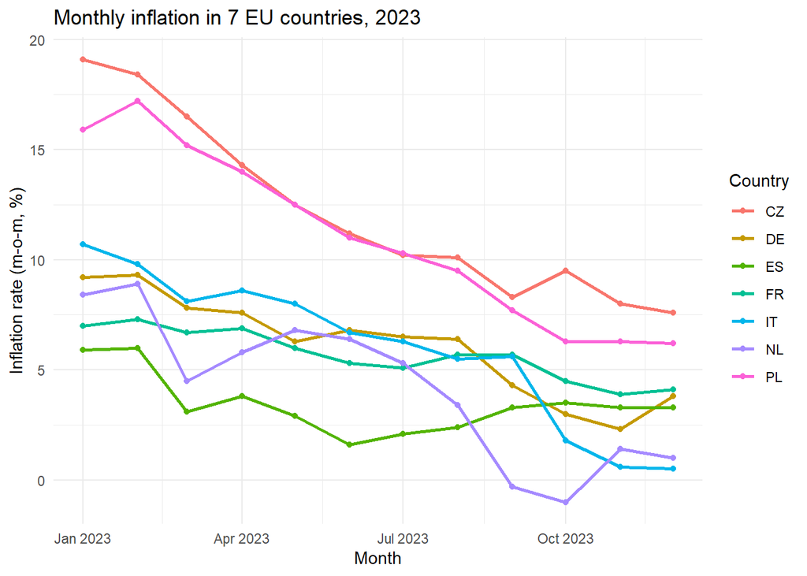

```r
ggplot(data2, aes(x = TIME_PERIOD, y = values, color = geo, group = geo)) +
  geom_line(size = 1) +
  geom_point() +
  labs(
    title = "Monthly inflation in 7 EU countries, 2023",
    x = "Month",
    y = "Inflation rate (m-o-m, %)",
    color = "Country"
  ) +
  theme_minimal()
```

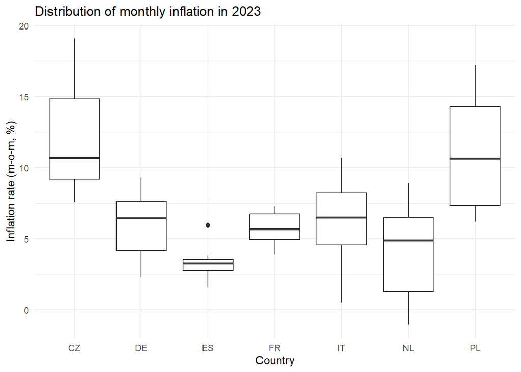

```r
ggplot(data2, aes(x = geo, y = values)) +
  geom_boxplot() +
  labs(
    title = "Distribution of monthly inflation in 2023",
    x = "Country",
    y = "Inflation rate (m-o-m, %)"
  ) +
  theme_minimal()
```

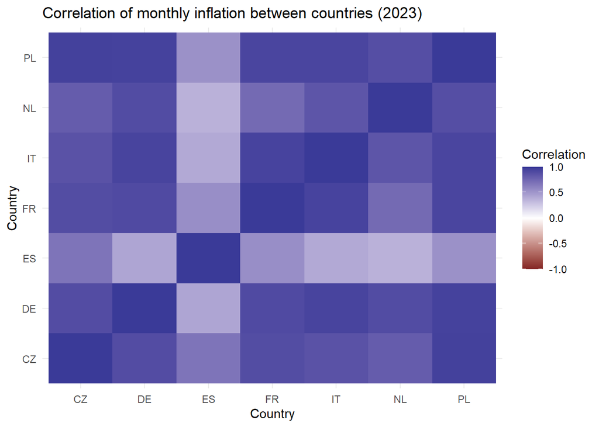

```r
cor2 <- as.data.frame(cor) %>%
  mutate(country1 = rownames(cor)) %>%
  pivot_longer(
    cols = -country1,
    names_to = "country2",
    values_to = "corr"
  )
ggplot(cor2, aes(x = country1, y = country2, fill = corr)) +
  geom_tile() +
  scale_fill_gradient2(
    limits = c(-1, 1),
    midpoint = 0
  ) +
  labs(
    title = "Correlation of monthly inflation between countries (2023)",
    x = "Country",
    y = "Country",
    fill = "Correlation"
  ) +
  theme_minimal()
```

This heatmap shows how similar the inflation movements were between the seven EU countries in 2023. Darker blue means a strong positive correlation (the countries’ inflation moved in the same direction). Lighter areas mean a weaker relationship.

```r
ci <- data2 %>%
  group_by(geo) %>%
  summarise(
    n    = n(),
    mean = mean(values, na.rm = TRUE),
    sd   = sd(values, na.rm = TRUE)
  ) %>%
  mutate(
    se        = sd / sqrt(n),
    t_crit    = qt(0.975, df = n - 1),
    ci_lower  = mean - t_crit * se,
    ci_upper  = mean + t_crit * se
  )
ci
```

```
## # A tibble: 7 × 8
##   geo       n  mean    sd    se t_crit ci_lower ci_upper
##   <chr> <int> <dbl> <dbl> <dbl>  <dbl>    <dbl>    <dbl>
## 1 CZ       12 12.1   4.04 1.17    2.20     9.57    14.7
## 2 DE       12  6.11  2.30 0.665   2.20     4.64     7.57
## 3 ES       12  3.43  1.33 0.384   2.20     2.59     4.28
## 4 FR       12  5.68  1.15 0.332   2.20     4.95     6.41
## 5 IT       12  6.02  3.43 0.991   2.20     3.83     8.20
## 6 NL       12  4.22  3.32 0.958   2.20     2.11     6.33
## 7 PL       12 11.0   3.96 1.14    2.20     8.49    13.5
```

Czech Republic (CZ)Mean inflation: 12.1%95% CI: 9.57% to 14.7% CZ has the highest average inflation and a wide interval, meaning inflation was high and quite variable. Poland (PL)Mean: 11.0%95% CI: 8.49% to 13.5% Poland also shows very high inflation with large variability. Italy (IT)Mean: 6.02%95% CI: 3.83% to 8.20% The interval is wide, showing high volatility, even though the average level is moderate. Germany (DE)Mean: 6.11%95% CI: 4.64% to 7.57% Germany’s CI is narrower, meaning inflation was more stable. France (FR)Mean: 5.68% 95% CI: 4.95% to 6.41% France has one of the smallest intervals, indicating very stable inflation. Netherlands (NL)Mean: 4.22%95% CI: 2.11% to 6.33% The interval is relatively wide because NL had large monthly fluctuations, including negative inflation. Spain (ES)Mean: 3.43% (lowest)95% CI: 2.59% to 4.28% Spain has both the lowest inflation and one of the narrowest CIs, showing very stable and low inflation.

```r
two_ctr <- c("PL", "DE")
data_two <- data2 %>%
  filter(geo %in% two_ctr)
t_test <- t.test(
  values ~ geo,
  data = data_two,
  var.equal = FALSE
)
t_test
```

```
##
##  Welch Two Sample t-test
##
## data:  values by geo
## t = -3.7078, df = 17.687, p-value = 0.001651
## alternative hypothesis: true difference in means between group DE and group PL is not equal to 0
## 95 percent confidence interval:
##  -7.680004 -2.119996
## sample estimates:
## mean in group DE mean in group PL
##         6.108333        11.008333
```

Germany had a significantly lower average inflation rate than Poland in 2023 (p = 0.001651).